# Random Analysis on English Premier league

Abinash Mallick

12/6/2021

##Premier League - The Stage

English Premier League - Most exciting domestic football league in the world. With the presence of superstars like Mo Salah, Cristiano Ronaldo, Harry Kane, Kavin De Bruyne and Acknowledgable minds in football world like Pep Guardiola, Jugern Klopp, Thomas Tuchel, Antonio Conte, Marcelo Bilesa it attracts viewrs from all over the world. Let’s Analyse some of the pattern in this league with help of data. Let’s dig in.

The dataset we’re using is a dataset on kaggle containing information about more than 10,000 Premier League matches played. To get the dataset [click here](https://www.kaggle.com/irkaal/english-premier-league-results).

We will use R libraries “tidyverse”, “tidyr”, “psych”, “ggsci”, “ggpubr”, “rshape” & “rshape2” in this project

## Downloading and importing the Dataset to R Studio

we can download the data set from [here](https://www.kaggle.com/irkaal/english-premier-league-results). Then import it with below instruction.

```r
EplData <- read.csv("EplResults93-21.csv", header = TRUE, sep = ",")
```

The data set is now imported to R Studio.

## Data Preparation and Cleaning

In any data analysis project,It is very necessary to clean the real world raw data and ready it for our analysis. There could be wrong values, missing values that need to be dealt with. Along with that, we might want to add new columns which are useful for our analysis to the dataset, we might want to merge a few datasets together, this should be done as a preliminary step.

First we have to install all the libraries we are gonna use to perform our task. let’s start

```r
install.packages("tidyverse")
library(tidyverse)
install.packages("tidyr")
library(tidyr)
install.packages("ggsci")
library(ggsci)
install.packages("ggpubr")
library(ggpubr)
install.packages("psych")
library(psych)
install.packages("dplyr")
library(dplyr)
install.packages("reshape2")
library(reshape2)
```

```r
install.packages("ggplot2")
library(ggplot2)
```

Now let’s clean the data In our case, there are lots of missing values. so we want to remove those rows from the data set.

```r
clean <- drop_na(EplData)
```

The data set is now dropped all the missing values and store in the “clean” data set.

Next we don’t need time and year in the DatetIime column. so we have to extract Date and Month and store those values in different column.

```r
clean$DateTimeN <- strptime(clean$DateTime, format = "%Y-%m-%dT%H:%M:%SZ")
clean$Day <- format(clean$DateTimeN, "%d")
clean$Month <- format(clean$DateTimeN, "%m")
clean <- clean[, !(names(clean) %in% c("DateTime", "DateTimeN"))]
```

Now or data is clean and reay for the analysis.

## Analysis and Visualization

Now that we have prepared our dataset, we can use it to get interesting analysis and visualisation. For that we will be using data visualisation libraries, ggplot2, ggpubr, ggsci.

Before plotting graphs, Let’s first get some insights from our dataset using the describe() function provided by “psych” library.

```r
pivot <- clean[ , c("Season", "FTHG", "FTAG", "HTHG", "HTAG", "HS", "AS", "HST", "AST", "HC", "AC", "HF", "AF", "HY", "AY", "HR", "AR", "Month", "Day")]
insight <- describe(pivot)
```

### Season-wise analysis- Goal scored per season

Let’s look at the data and compare the trends based on season. Here we will first install the “ggsci” and “ggpubr” libraries and sort the data according to the season by using `aggregate()` function. Then we will plot a bar graph comparing Goals per Season.

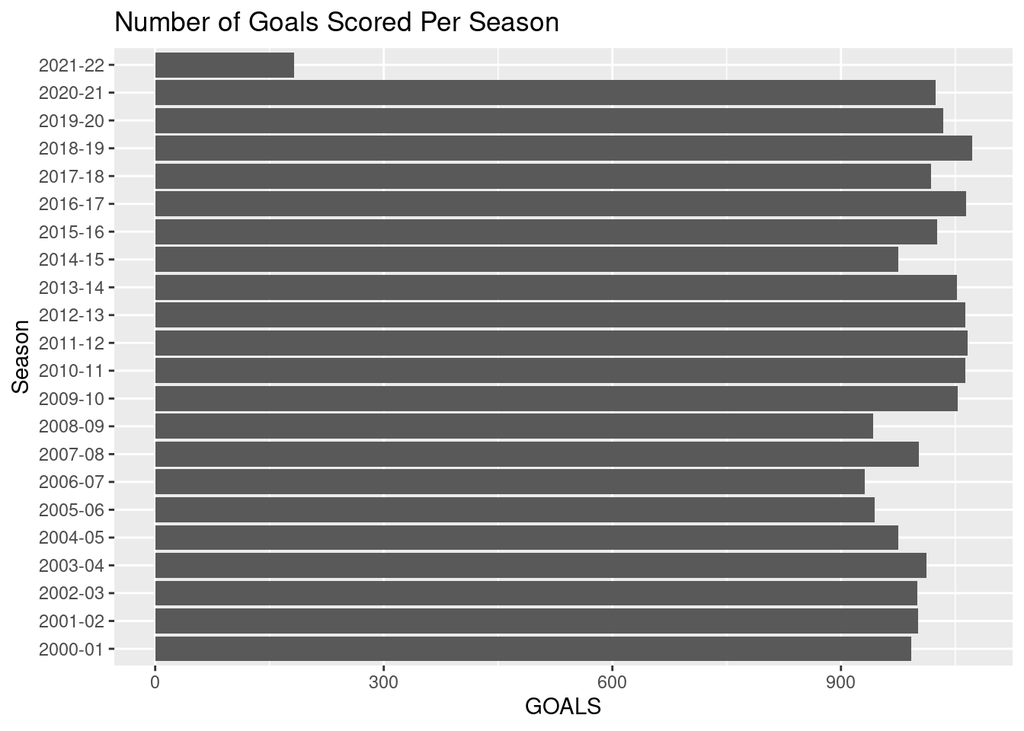

```r
seasonwise <- aggregate(cbind(FTHG, FTAG, HTHG, HTAG, HS, AS, HST, AST, HC, AC, HF, AF, HY, AY, HR, AR) ~ Season, pivot, sum)
seasonwise <- seasonwise %>% mutate(GOALS=FTHG+FTAG)
ggplot(data=seasonwise, aes(x=GOALS, y=Season)) +
  geom_bar(stat = "identity") +
  labs(title = "Number of Goals Scored Per Season")
```

#### Home Goals vs Away Goals

We will now plot a double barplot for the same using Home Goals and Away Goals. So we need to `melt` our data which lets us use the comparison parameter as hue.

```r
Epl_melted <- seasonwise[ , c("Season", "FTHG", "FTAG")]
EPL_melt = melt(Epl_melted)
```

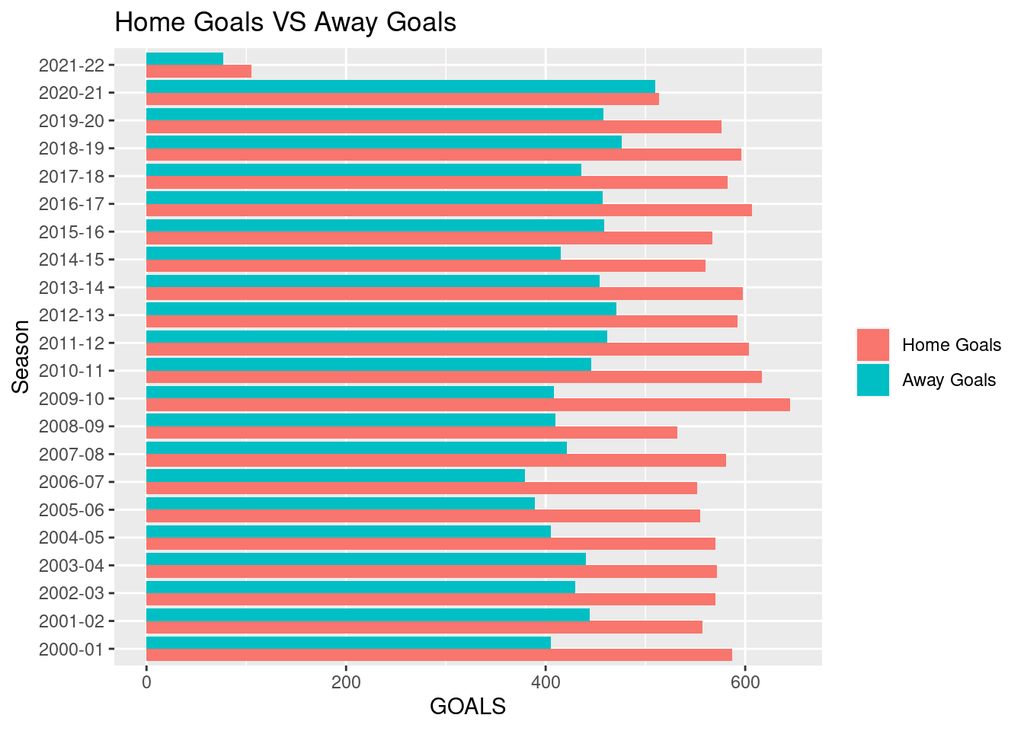

```r
EPL_melt <- rename(EPL_melt, HA = variable, GOALS= value)
ggplot(data=EPL_melt, aes(x=GOALS, y=Season, fill=HA)) +
  geom_bar(stat = "identity", position = "dodge")+
  theme(legend.title = element_blank())+
  scale_fill_discrete(labels= c('Home Goals', 'Away Goals')) +
  labs(title = "Home Goals VS Away Goals")
```

#### Plotting a heatmap for distribution of goals per month

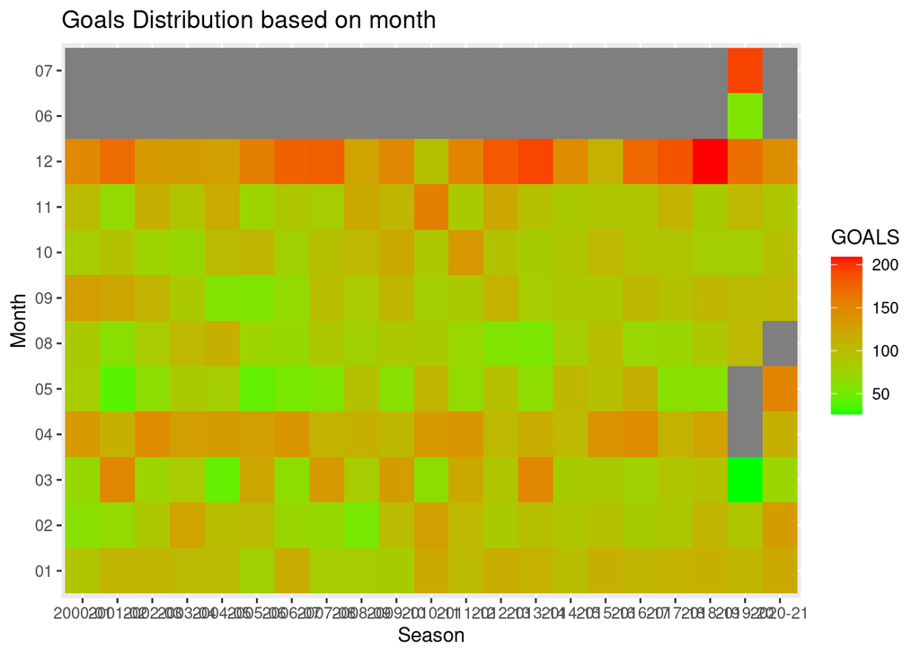

```r
EPL_heat <- aggregate(cbind(FTHG, FTAG) ~ Month + Season, pivot, sum)
EPL_heat <- EPL_heat %>% mutate(GOALS=FTHG+FTAG)
EPL_heat <- EPL_heat[, !(names(EPL_heat) %in% c("FTHG", "FTAG"))]
EPL_heat <- pivot_wider(EPL_heat, names_from = Month, values_from = GOALS)
EPL_heat <- EPL_heat[-22,]
EPL_heat <- melt(EPL_heat)
colnames(EPL_heat) <- c("Season", "Month", "GOALS")
ggplot(EPL_heat, aes(Season, Month))+
  geom_tile(aes(fill= GOALS))+
  scale_fill_gradient(low = "green", high = "red")+
  labs(title ='Goals Distribution based on month' )
```

The above graphs tells us more about the data.

1. No games are played in the months of June and July, thus no goals are scored.
2. Almost every year, December has seen the most number of goals. This is because december sees the most number of matches played.
3. The 2019-20 season was disrupted due to the covid pandemic. Games were played in June and July instead of April and May under project restart.
4. The season ends mid-May, thus the low number of goals scored in May.

Let’s plot another graph of Goals scored per game.

```r
EPL_count <- aggregate(FTHG ~ Month + Season, pivot, length)
EPL_count <- pivot_wider(EPL_count, names_from = Month, values_from = FTHG)
EPL_count <- EPL_count[-22,]
EPL_count <- melt(EPL_count)
```

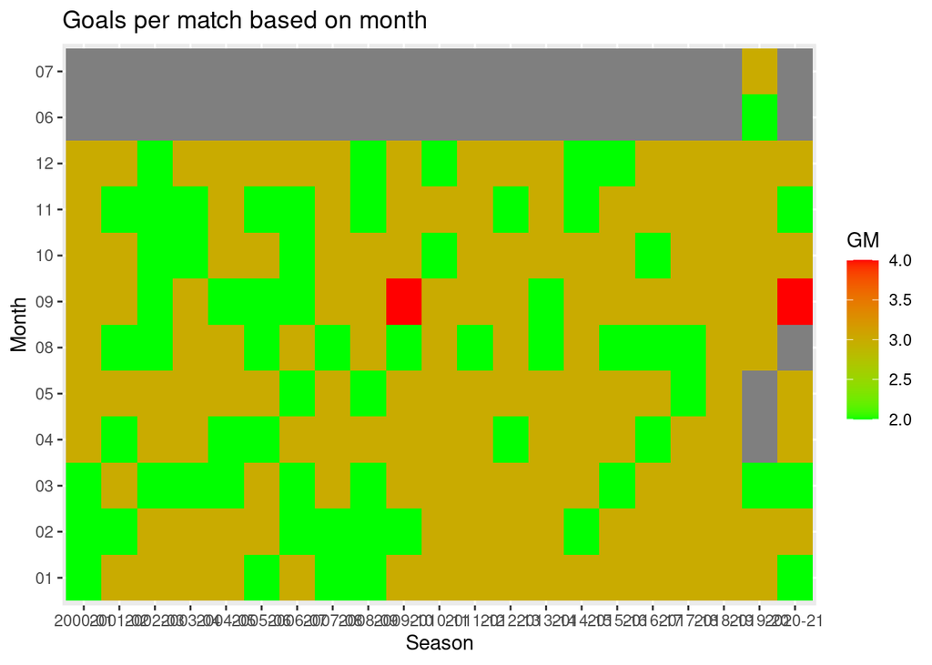

```r
colnames(EPL_count) <- c("Season", "Month", "FTHG")
EPL_heat$GM = round(EPL_heat$GOALS / EPL_count$FTHG)
FINAL <- EPL_heat[, -3]
ggplot(EPL_heat, aes(Season, Month))+
  geom_tile(aes(fill= GM))+
  scale_fill_gradient(low = "green", high = "red")+
  labs(title = 'Goals per match based on month')
```

Here we can observe that Goals per game remains fairly obvious which shows that there are no real visible “Settling period”, “Thriving period” or “Burnout period” or at least it doesn’t affect the scoreline much. Pretty interesting that September witnessed the highest goals per game twice.

###COMEBACKS AFTER HALFTIME IN DIFFERENT CASES

We are curious after seeing the previous analysis. Does Home crowd makes team comeback more often after ressults in halftime gone against them? Let’s see!

we will use only data from 2015-16 season after Jurgen Klopp era strated at Anfield.

```r
EPL15 <- clean %>% slice(c(5701:8050))
FPL_result <- EPL15[ , c("Season", "HomeTeam", "AwayTeam", "HTR", "FTR")]
FPL_result <- FPL_result[FPL_result$HTR != "D", ]
FPL_result$Results <- if_else(FPL_result$HTR == FPL_result$FTR, "No Comeback", "Comeback")
COMEBACKS <- FPL_result[FPL_result$Results == "Comeback", ]
NOCOMEBACKS <- FPL_result[FPL_result$Results == " No Comeback", ]
HCOMEBACKS <- COMEBACKS[COMEBACKS$HTR == "A", ]
ACOMEBACKS <- COMEBACKS[COMEBACKS$HTR == "H", ]
ANALYSIS <- data.frame("Comeback", "HomeComeback", "AwayComeback")
ANALYSIS$Comeback <- length(COMEBACKS$Results == "Comeback" )
ANALYSIS$HomeComeback <- length(HCOMEBACKS$Results == "Comeback")
ANALYSIS$AwayComeback <- length(ACOMEBACKS$Results == "Comeback")
ANALYSIS <- ANALYSIS[ -c(1:3)]
BHCOMEBACKS <- HCOMEBACKS[HCOMEBACKS$HomeTeam %in% c("Arsenal", "Liverpool", "Chelsea", "Man United", "Tottenham", "Man City"), ]
BACOMEBACKS <- ACOMEBACKS[ACOMEBACKS$HomeTeam %in% c("Arsenal", "Liverpool", "Chelsea", "Man United", "Tottenham", "Man City"), ]
ANALYSIS$BIG6HomeComeback <- length(BHCOMEBACKS$Results == "Comeback")
ANALYSIS$BIG6AwayComeback <- length(BACOMEBACKS$Results == "Comeback")
ANALYSIS <- melt(ANALYSIS)
```

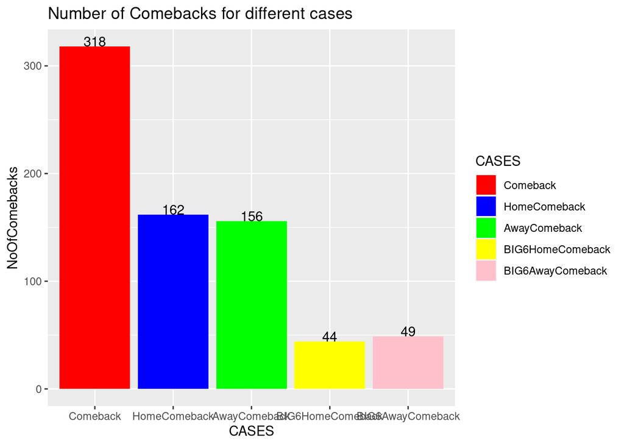

```r
colnames(ANALYSIS) <- c("CASES", "NoOfComebacks")
ggplot(data=ANALYSIS, aes(x=CASES, y=NoOfComebacks, fill= CASES))+
  geom_bar(stat = "identity")+
  labs(title = "Number of Comebacks for different cases")+
  scale_fill_manual(values = c("Comeback" = "red",
                               "HomeComeback" = "blue",
                               "AwayComeback" = "green",
                               "BIG6HomeComeback" = "yellow",
                               "BIG6AwayComeback" = "pink"))+
  geom_text(aes(label = NoOfComebacks), vjust = 0)
```

## Conclusion

The main objective of this article was to find ot does Home crowds really affect the result of the match. As we here find in our analysis some mixed opinion we will do another in depth analysis on it!